# Error and Condition Handling in R

July 30, 2019

## Outline

- Built in conditions
- Controlling the output of warnings
- Checking for errors and stopping
- Capturing errors and handling them

## Built in conditions

- message:
  - ‘simple’ diagnostic messages
- warning:
  - A warning message but execution continues
- stop:
  - An error message that can cause execution is stop

## Using message instead of print

- Instead of using ‘print’ for debugging, use message().
- It goes to stderr(). Better control with using sinks

```r
add <- function (...) {
   message(paste("add:Parameters:", paste(..., collapse = ", ")))
   result <- sum(...)
   message(paste("add:returned:", result))
   result
   invisible()
}
add(1:10)
```

```
## add:Parameters: 1, 2, 3, 4, 5, 6, 7, 8, 9, 10
```

```
## add:returned: 55
```

## You can suppress the messages

- Suppress messages instead of adding/removing print statements

```r
add <- function (...) {
   message(paste("add:Parameters:", paste(..., collapse = ", ")))
   result <- sum(...)
   message(paste("add:returned:", result))
   result
   invisible()
}
suppressMessages(add(1:10))
```

Now you do not have to comment them out!

## Warning messages

- Used to advise when business logic is handling a strange situation, such as:
  - using default parameters,
  - type casting weirdness i.e. as.numeric(“a”)
- Works similar to message() but has output controls

```r
test <- function() {
    warning("The British are coming",
            call. = TRUE, # make 'call' part of the message
            immediate. = TRUE) # override getOption('warn'))
}
test()
```

## Controlling Output: When to print

- Output is controlled with global options
  - accessor: getOption(‘<OPTION>’)
  - mutator: options(<OPTION> = <VALUE>)
- <Option>: warn
  - Controls when the warnings are printed
  - Allowed values:
    - -1: suppress output (technically warn < 0)
    - 0: printed after the top-level function has complete
    - 1: printed as they occur
    - 2: convert into errors (technically warn > 1)

## Controlling Output: Message length

- <Option>: warning.length
  - Truncates the length of each message (error and warning)
  - values: 100…8170 default:1000 (long)

```r
options(warning.length = 100)
warning(msg)
```

```
## Warning:
## SAISXBBULMPFRAMTTEKROXCPWHOSCINBGGHPGQKAUFGYQQAFQMCAIGUOVEWG…
```

## Controlling Output: Number of messages printed

- <Option>: nwarning
  - When warn = 0, the error and warn messages are buffered
  - sets the size of the buffer. Default: 50

## Accessing the warnings

- If getOption(‘warn’) == 0 then there is a buffer of warning messages
- warnings(…) prints this buffer
- Parameters “…” are passed to cat() to control output
- The buffer is a variable called last.warning
- last.warning is:
  - a named list
  - undocumented (subject to change)
  - use it in the console but not in your scripts
  - does not always exist

## Controlling Output: Modifying the message

- <Option>: warning.expression
  - custom code is run with each call to warning()

```r
options(warning.expression = quote(getwd()))
warning("Test")
```

```
## Warning: Test
```

BUG in ioslides (?) because this code outputs the following in the console:

```
## [1] "/Users/jpeach/git/ocrug/presentations/2019-07-30_error_and_condition_handling_in_R"
```

## Warning messages suppression

- Just like messages, we can suppress the warnings

```r
test <- function() {
    warning("The British are coming",
            call. = TRUE, # make 'call' part of the message
            immediate. = TRUE) # override getOption('warn'))
}
suppressWarnings(test())
```

- The warning is not printed

```r
warnings()
```

and it is not stored in the buffer

## Error Messages

- Used when there is an unrecoverable error
- By default, program execution is halted

```r
test <- function() {
    stop("In the name of love",
            call. = TRUE) # call is part of the message
}
test()
```

## Error in test() : In the name of love

## What was the last error?

- Forgot the details of the last error message, you can use

```r
geterrmessage()
```

## Error: In the name of love

- A string with the last error message is returned
- A \n is appended to the error message

## stopifnot()

- Throw an error if any condition is FALSE
- No message is returned

```r
stopifnot(...)
```

… is any number of logical R expressions which should be TRUE

```r
stopifnot(A, B)
# Is short hand for
if ( any(is.na(A)) || !all(A) || any(is.na(B)) || !all(B)) stop(...)
```

NULL is treated as TRUE

## Example: stopifnot()

- Generally used to check function parameters
- Wrapper function for sum that checks:
  - all parameters are integer
  - there must be a non-zero length vector
  - there are no NULLs or NANs

```r
Sum <- function(...){
   stopifnot(is.integer(...), length(...) > 0,
             !is.null(...), !is.nan(...))
   as.integer(sum(...))
}
Sum(1L:10L)
```

```
## [1] 55
```

## Condition System

- message(), warning(), stop() are built on the Condition System
- It is used for error handling but is more flexible than that
- Consists of three parts
  - Signalling Condition
  - Handling Condition
  - Restarting (Advanced topic)
- The task of handling the error is split between the Handler and the Restart

## Components

- Signaller
  - A method that raises / throws and exception object
  - Creates an object derived from the S3 class ‘condition’
  - Language framework handles its execution path
  - message(), warning() and stop() are signallers
- Handler
  - Agrees to catch / process exception of specific classes
  - Handles exception only from the call stack below it
  - Handlers lower on the stack may capture exception

## Exceptions - Sequence of execution

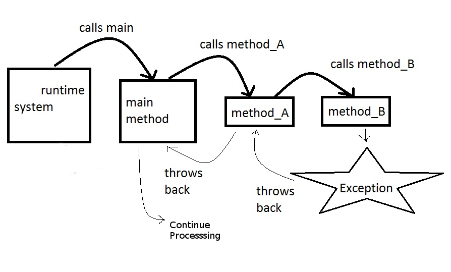

## Exceptions

- Errors are handled by:
  - Exiting the failing function
  - Calling function can recover or fail itself
- Primary issue is that the stack unwinds
  - Recovery code must do so without the context of the failing function

## tryCatch

- Unwinds the call stack

```r
tryCatch(expression,
  condition_class_1 = function(var) ...,
  condition_class_2 = function(var) ...,
  finally = ...
)
```

- expression: must be a single expression, use { }
- var: is the condition object
- tryCatch returns the value of expression or one of the condition_class
- If the condition is not handled by one of the condition_class it moves up the call stack

## tryCatch: Handler not invoked

```r
`%+%` <- function(lhs, rhs) {
   if (!is.integer(lhs) || !is.integer(rhs)){
      stop("parameters must be numeric")
   }
   lhs + rhs
}
tryCatch( { 5L %+% 4L },
   error = function(e) 0
)
```

```
## [1] 9
```

- There was no error so the handler ‘error’ was not invoked
- tryCatch returned the value of the expression

## tryCatch: Handler invoked

```r
`%+%` <- function(lhs, rhs) {
   if (!is.integer(lhs) || !is.integer(rhs)){
      stop("parameters must be numeric")
   }
   lhs + rhs
}
tryCatch( { 5L %+% 4 },
   error = function(e) 0
)
```

```
## [1] 0
```

- stop() was called because 4 is double not integer
- tryCatch returned the value of the ‘error’ handler

## tryCatch: No warning handler

```r
`%+%` <- function(lhs, rhs) {
   if (is.double(rhs)) {
      rhs = as.integer(rhs); warning("casting rhs to integer")
   }
   if (!is.integer(lhs) || !is.integer(rhs)){
      stop("parameters must be numeric")
   }
   lhs + rhs
}
tryCatch( { 5L %+% 4 },
   error = function(e) 0
)
```

```
## Warning in 5L %+% 4: casting rhs to integer
```

```
## [1] 9
```

- Sum is computed and a warning is displayed

## tryCatch: finally

```r
tryCatch( {
   text <- 'foo'
   message(text)
   },
   message = function(e) {
      text <- paste(conditionMessage(e), 'bar')
      text # This is the value returned by tryCatch. Different environment
      },
   finally = {
      # This block is run iff a handler is called
      print(text) # handler does not alter value
   }
)
```

```
## [1] "foo"
```

```
## [1] "foo\n bar"
```

## Comment on Condition System

- I showed you how to use R like you use error systems in Java/python
- R has a much more powerful system that is based on lisp
- Code is not “rolled-up” the call stack, it can be restarted
- We can build custom conditions and handle them
- The Condition System can be used for much more than errors